# COVID-19 Analysis in South Korea

Group 86 - Jana Schneider, Jana Jeggle, Felix Heim, Leon Gaertner

4 12 2020

```r
#general libraries
library(magrittr)
library(data.table)
library(ggplot2)
library(tidyr)
library(dplyr)
library(ggpubr)
#required libraries for Claim 1
library(patchwork)
library(hrbrthemes)
#required libraries for Claim 2
library(maps)
library(ggrepel)
library(rgeos)
library(sf)
library(rnaturalearth)
library(rnaturalearthdata)
library(maptools)
library(sp)
library(raster)
library(mapproj)
```

```r
#import data files
time <- fread("./extData/Time.csv")
policy <- fread("./extData/Policy.csv")
policy1 <- fread("./extData/Policy.csv")
RKI_data <- fread("./extData/DE_InfectionCases.csv")
patientinfo <- fread("./extData/PatientInfo.csv")
case <- fread("./extData/Case.csv")
searchtrend <- fread("./extData/SearchTrend.csv")
region <- fread("./extData/Region.csv")
weather <- fread("./extData/Weather.csv")
timeProvince <- fread("./extData/TimeProvince.csv")
south_korea <- raster::getData("GADM", country = "South Korea", level = 1)
```

## Initial Motivation

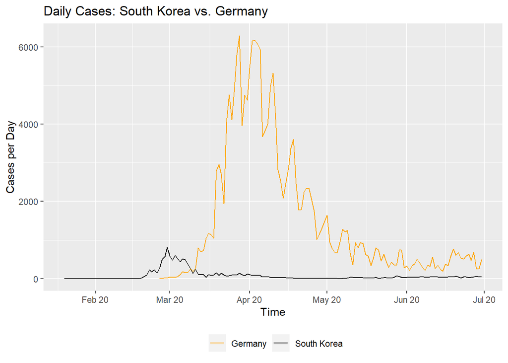

- After a massive increase in the number of daily cases in South Korea, one can observe that these numbers decline remarkably in a short time period and continued to stay on a constant low level.
- Germany on the other hand struggled with a multiple of daily cases and these numbers remained on a high level for a longer time period before dropping again.
- Both countries Germany and South Korea are considered as industry nations, thus we can assume that there is at least a small similarity in terms of life quality, infrastructure, health care system, etc. However, South Korea has more than twice the number of inhabitants per km² and still showed low numbers of infection cases. Therefore, it seems interesting to further investigate what happened in South Korea.

## Claim 01

#### By imposing a multitude of different types of policies, the government of South Korea managed to reduce the number of daily infection cases.

**Our initial motivation:**

- South Korea generally showed covid cases of much lower level (compared to Germany). In addition, South Korea was able to drastically reduce its number of daily covid cases from its peak end of February. As social-distancing policies are known to be a global measure to contain the spread of the virus, we investigate their influence of policies on the course of the pandemic in South Korea.

**Claim description in more detail:**

- As the number of infection cases in South Korea increased heavily, the government became more active in terms of introducing new restricting policies across all areas of life with the aim to decrease the number of daily infection cases.

**Our approach:**

- First, we inspect the different types of policies and when they were imposed by the government during the period from January to July 2020.
- Then, we show an example of imposed policies in the areas of administration, education and society to outline the overlap of different policies within the same time period.
- Finally, we inspect whether there is a significant association between the number of policies and the development of the number of daily infection cases.

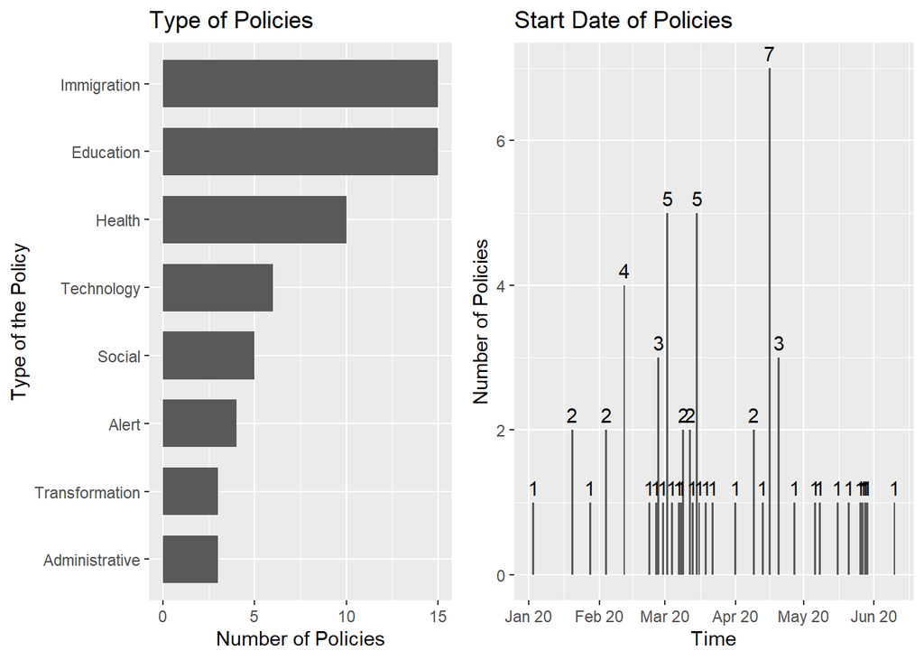

**Short Analysis**

- In total, 61 policies were introduced by the government of South Korea during the time period from January to June 2020.
- The number of immigration and education policies dominate other policies. This is due to the fact that immigration policies are counted for each country and education policies for each school type.
- Shortly after the number of infection cases surged the government of South Korea reacted with numerous policies in all kinds of areas. Many policies in the middle of April result from online-school opening policies that all took place at once for each type of school.

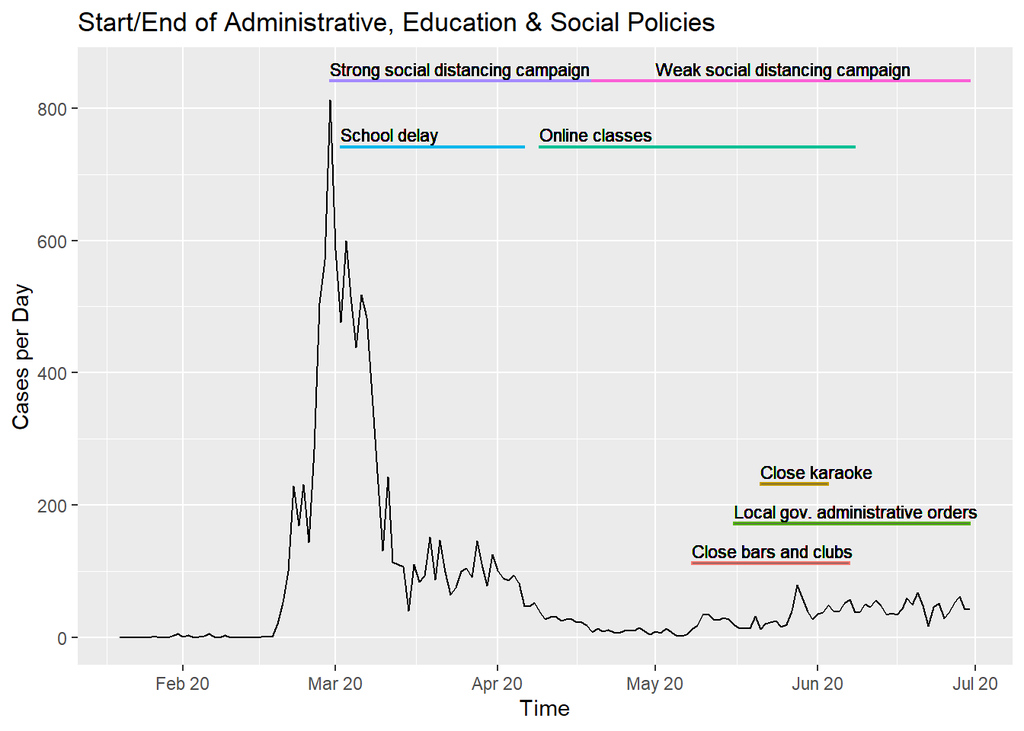

**Short Analysis**

- After the number of daily cases have reached peak end of February, numerous policies with the aim of social distancing, such as delaying school start, were introduced. It seems that these policies helped reducding the number of daily cases. (Note: the figure above only displays a fraction of policies)
- In the beginning of May, after the number of daily cases tended to increase again, further public indoor gathering places were forced to close.

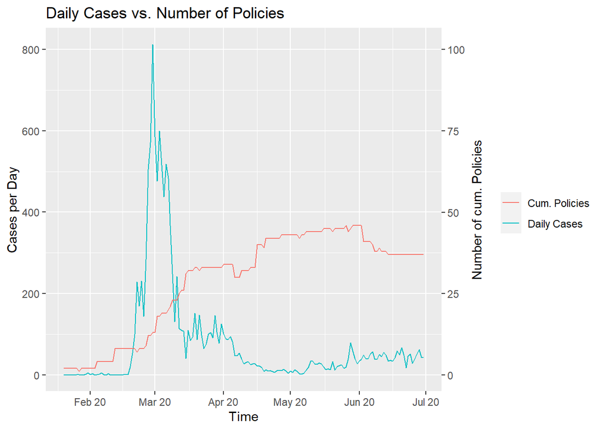

**Short Analysis**

- The number of active policies increased heavily when the number of daily cases rose to its peak end of February and kept increasing until June
- However, as the figure shows, some policies were also removed again.
- What is striking is that there seems to be a lag between the introduction of new policies and its assumed causing effect in terms of reduced daily cases.
- Therefore, we first inspect the Pearson correlation between both variables before having a closer look at the cross-correlation to gain further insights.
- We use the Pearson correlation throughout both tests as our variables “Daily Cases” and “Number of Policies” are of quantitative nature and we presume a linear relationship between those variables. Furthermore, we see no indication for considerable outliers that could distort the results.

**Person Correlation**

```
##
##  Pearson's product-moment correlation
##
## data:  merge_CasesMeasures$cumulativeNumbers and merge_CasesMeasures$daily_cases
## t = -2.6668, df = 161, p-value = 0.008439
## alternative hypothesis: true correlation is not equal to 0
## 95 percent confidence interval:
##  -0.34838820 -0.05365902
## sample estimates:
##        cor
## -0.2056829
```

**Interpretation:**

- We presume that there is no correlation between the variables “Daily Cases” and “Number of Policies” (null hypothesis) and test on the common significance level of alpha = 0.05. As the direction of correlation is unknown, we use the double-sided hypothesis test.
- As result we get a Pearson correlation of -0.2 which indicates a low negative correlation between “Daily Cases” and “Number of Policies”, meaning that more policies result in lower number of daily cases.
- The p-value is ~ 0.0, meaning the probability of obtaining test results at least as extreme as the results actually observed under the assumption that the null hypothesis is correct.
- So we reject our Ho and can conclude that there might be a correlation between those variables but based on our results we cannot be certain.

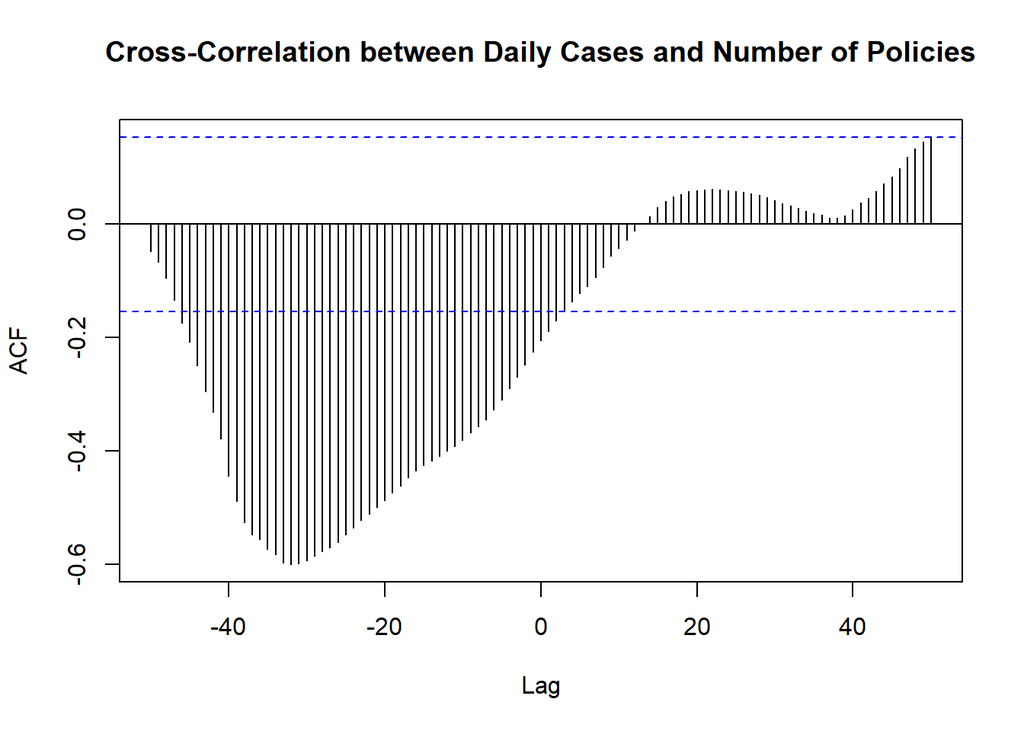

**Interpretation:**

- For the cross-correlation we again test with the Pearson correlation and therefore have the same assumptions as described earlier.
- The blue dashed lines show the boundaries of the 95% confidence interval.
- For a lag of zero we obtain the same results as already shown in our test above.
- However, as can be seen, the negative correlation increases from ~ -0.2 at lag 0 up to ~ -0.6 at lag -33.
- This indicates that increased number of policies are likely to lead to decreased number of daily cases about 30 days later.

**Discussion:**

- By testing the correlation between the variables “Daily Cases” and “Number of Policies” we wanted to show that a significant relationship between those two variables exists.
- Our results clearly show, by only considering these two variables, that one can assume a moderate negative correlation for a time lag of ~ 1 month.
- However, we need to take into account that there are multiple active policies in the same time period and also across different areas. The first two figures presented in this claim show the type of different introduced policies and their start dates while the following figure examplifies the overlap of various polices. Therefore, it is not possible to reduce the effect of declining number of daily cases to one or even a type of policies.
- Furthermore, there is need to consider various other possible impacts that could have caused this relationship.
- Nevertheless, it can be said that it is very likely that the different polices from the government had an influence on the decrease in numbers.

## Claim 02

#### The superspreader event in the Shincheonji Church in Feb. 2020 was one reason the Covid cases in South Korea turned out to be so intense in the first place.

**Our initial motivation:**

- When Covid first reach South Korea the number of cases was relatively low. However, with the “mysterious” patient Number 31, the serious increase in daily cases in South Korea began. A lot of people worldwide including the local government blamed a Christian ‘Cult’ for this, since one member seemed to have spread the virus.

**Claim description in more detail:**

- Without this particular spreader event in the Shincheonji Church in February in Daegu the Covid-spread would have been seriously lower.
- In fact, one could argue that without this spreader event and - to be specific - without the attendance of the church event by patient number “1200000031” (following called Patient 31) the Covid-spread in South Korea wouldn’t have been “serious” at all.

**Our approach:**

- In order to see, whether the public media was right, and the Church did indeed cause the first “serious” spread of the virus we first had a look at the Covid infections throughout South Korea that clearly indicated two main infection cluster.
- We then had a closer look at the Church cases compared to the overall daily cases and dived a bit deeper into the starting point of the church cluster
- Finally, we tried to understand how one local event can effect the whole country and created a map showing positively tested people related to the church traveling all over the country.

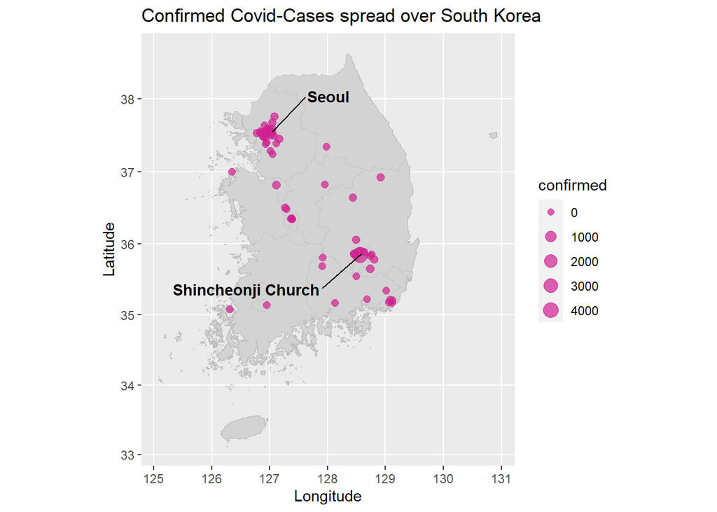

**Short Analysis**

- Seems like there were two hot-spots indeed! On around Seoul and one around the mysterious church event.
- Let’s have a closer look on this. How did the church related cases develop over time and did it have a significant impact on the overall daily cases?

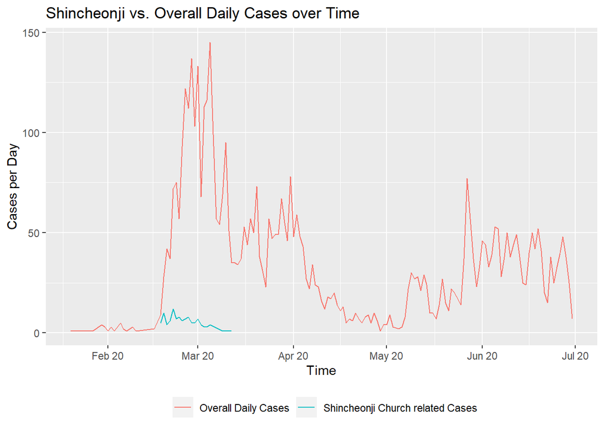

**Short Analysis**

- Mhm… doesn’t look that bad, does it? However, when we think about the fact that this is only one single event, the numbers are not that low at all…maybe the patientinfo table isn’t showing the whole picture.
- Also, in terms of time it still fits pretty well to the beginning of the first larger outbreak. Let’s dive a bit deeper. There has to be a reason why everyone was going nuts about this one! Can we find the top 10 infection reasons?

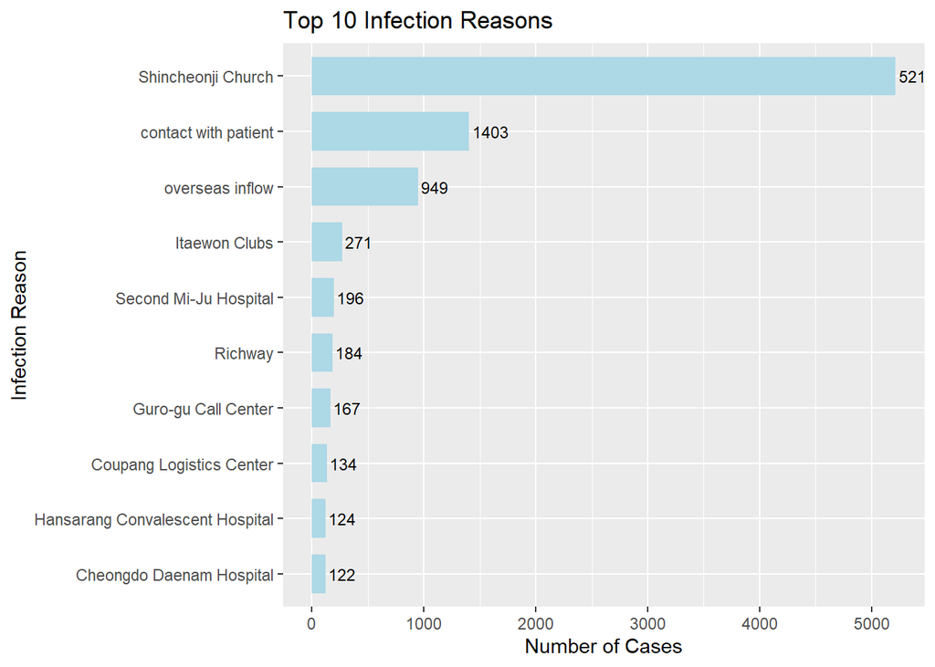

**Short Analysis:**

```
##        infection_case patient_id    sex age city infected_by contact_number
## 1: Shincheonji Church 1200000031 female 60s                            1160
##    symptom_onset_date confirmed_date released_date deceased_date    state
## 1:               <NA>     2020-02-18          <NA>          <NA> isolated
##    daily_cases
## 1:           9
```

Turns out in fact Patient Number 31, in her 60s, was diagnosed with Covid on Tuesday, 18th Feb 2020 as the first person related to the Shincheonji Church and she has an insane amount of contact numbers. No wonder Shincheonji Church cases were so high… imagine those 1160 contacts infecting even more people!

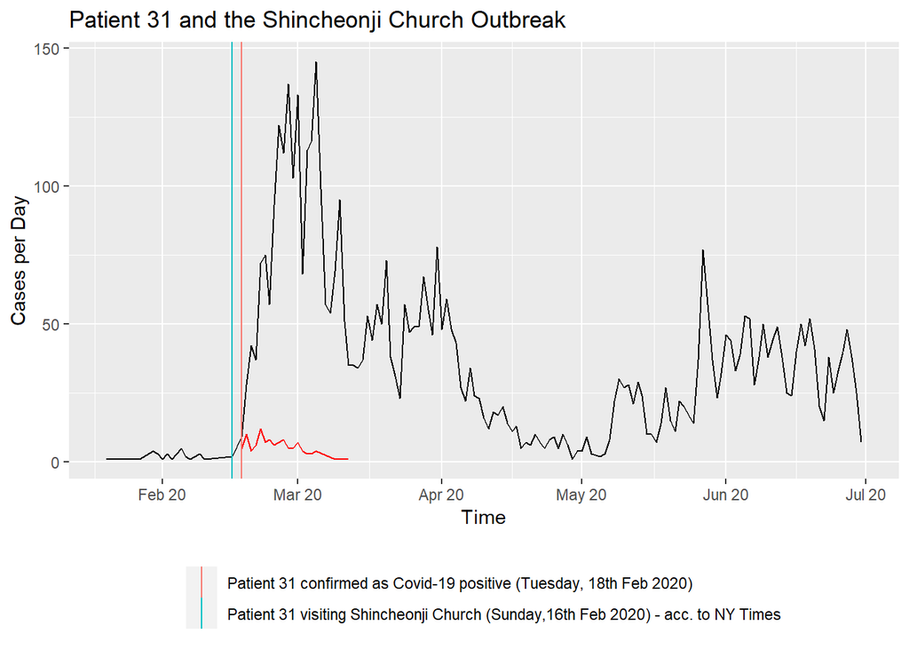

**Short Analysis:**

- This fits the timeline and development of overall cases pretty well. However, it still doesn’t provide a clear picture why the Church was blamed for the virus to go wild.
- Just because one event in Daegu results in an enormous amount of cases doesn’t necessarily mean, that the whole country will be affected by this.
- Did people travel outside of Daegu but where infected at the church by any chance?

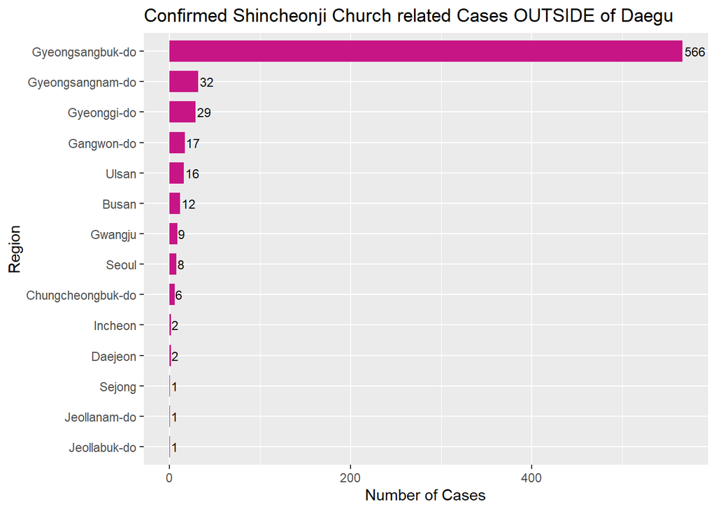

**Short Analysis:**

- Alright, indeed a couple of people. Gyeongsangbuk-do is probably close to Daegu, causing the high amount of cases?
- Are we able to plot this on a map showing where exactly this occurred?

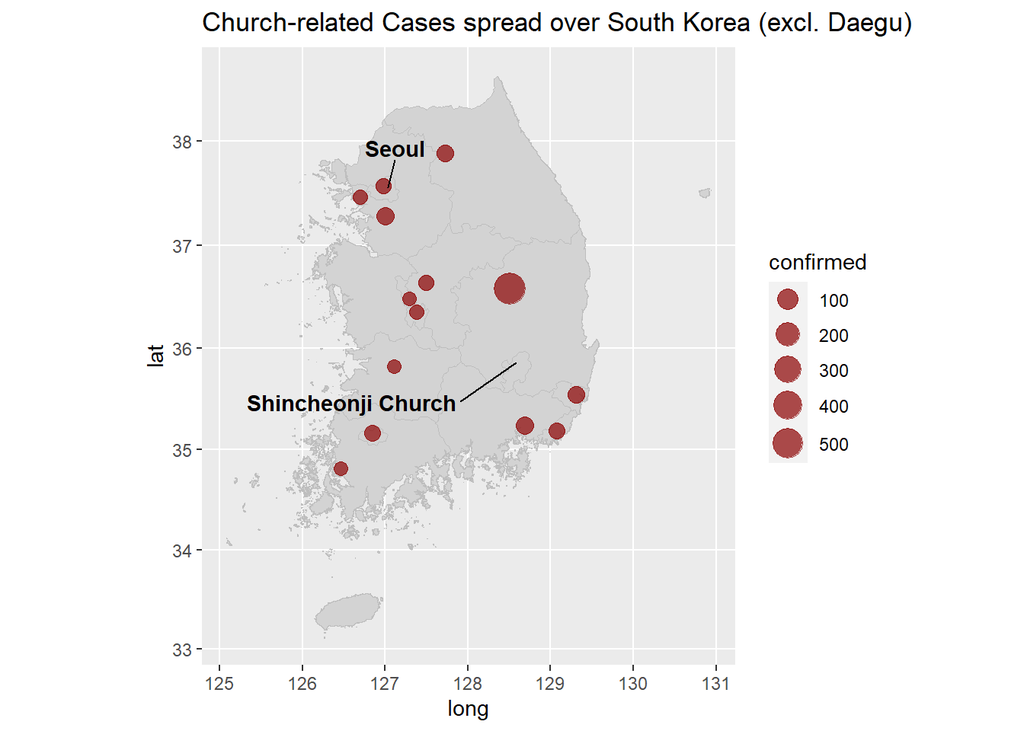

**Short Analysis**

- While obviously the most cases related to the church occurred in Daegu or close to Daegu, this map shows pretty well that people infected with covid that were somehow related to that church event, appeared all over the country.
- Thus, people traveling from Daegu to e.g. Seoul while being infected, might have cause the virus to spread even further. From that one outbreak in Daegu into the whole country - and maybe even further.

**Discussion**

To sum it up, YES, the Church Event had a serious impact on the Covid spread in South Korea. However we are not able to confirm the claim 100% stating that it was the number one reason the outbreak was so severe.

## Claim 03

#### The temperature level correlates with daily number of infection cases.

**Our initial motivation:**

- Concerning other viruses it is often said that the temperature level has an significant impact on the daily number of infection cases. So it is reasonable to inspect whether this is also true for COVID-19.

**Claim description in more detail:**

- Therefore, we analyse the association between the average temperature level and the number of covid cases per day within the period from January to June 2020. Thereby, we consider the daily cases and average temperature of the different provinces of South Korea. Within the time period from January to June 2020 the average temperature ranked between -8℃ and 30℃.

**Our approach:**

- First, we plot the existing data into a scatter plot in order to see the kind of underlying distribution. For this, we plot the average temperature on the x-axis and the number of daily infection cases on the y-axis. By inspecting the plot we then can decide whether to use a Pearson or Spearman test. Depending on the results of the test, we are able to reject or fail to reject our claim. As we want to show that temperature level associates with daily number of infection cases our null hypothesis formulates as follows: Ho : r = 0. Furthermore, we use the commonly used significance level of alpha = 0.05. Therefore, we will reject Ho if the p-value is below 0.05.

**Discussion**

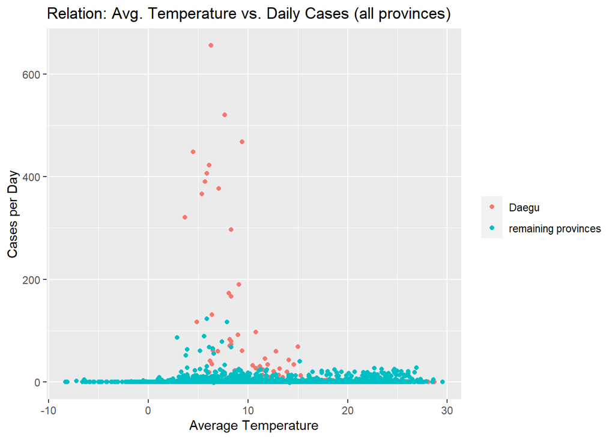

As can be seen above, the province Daegu has way higher numbers of daily infection cases and thus distorts the entire plot which is a typical characteristic for an outlier. Therefore, it is seems to be reasonable to plot the data without this province in order to get a better understanding on the relationship between temperature and number of daily infection cases in the remaining provinces. Nevertheless, we already can conclude that the data is not normally distributed. Also, the Spearman correlation test is more robust to outliers than the Pearson correlation test. Thus, we prefer the Spearman correlation test.

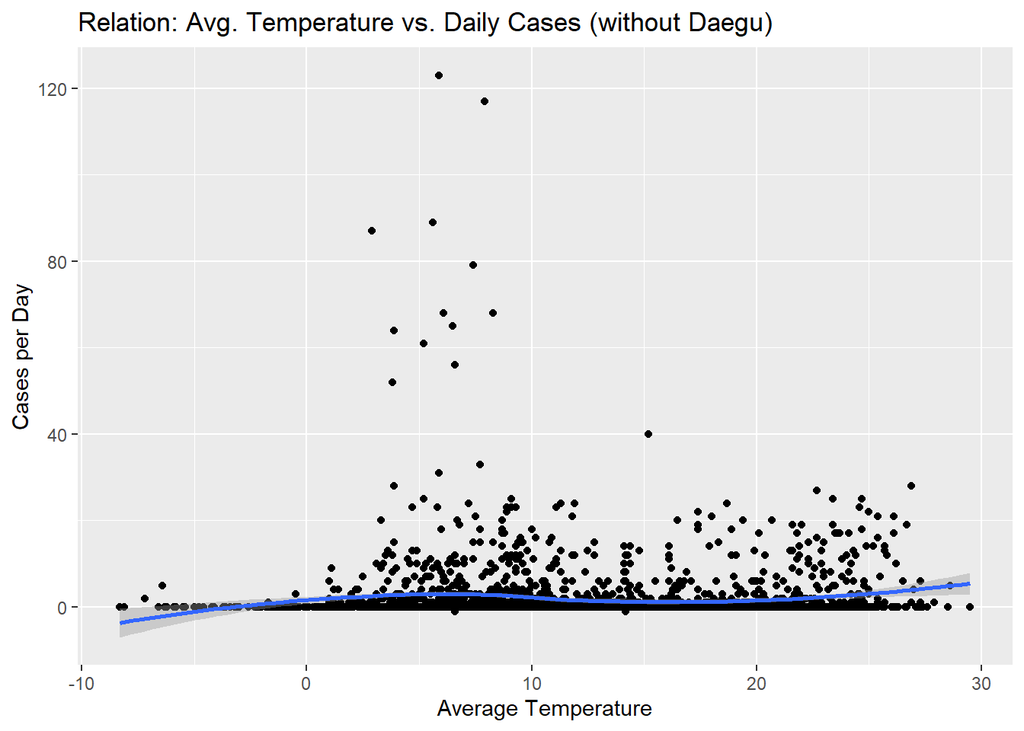

Without the data from the province Daegu it is possible to rectify the data points. However, no considerable correlation between the two variables can be seen.

```
##
##  Spearman's rank correlation rho
##
## data:  melted_dt$avg_temp and melted_dt$daily_cases
## S = 2743139003, p-value = 0.2566
## alternative hypothesis: true rho is not equal to 0
## sample estimates:
##        rho
## 0.02241774
```

```
## [1] 0.2565802
```

**Interpretation:**

The p-value of our performed Spearman correlation test is ~0.257 while our alpha-value is 0.05. As ~0.257 > 0.05 we fail to reject our Ho. Therefore, under the given circumstances, we have no evidence to suggest that there might be a significant correlation between the average temperature and the number of daily infection cases.

## Claim 04

#### Search data is related to the development of daily cases, thus could function as predictor for future outbreaks

**Our initial motivation:**

- Previous results showed that identifying covid outbreaks quickly is important to react appropriately, e.g. with social-distancing measures. It might thus be interesting to investigate factors which can possibly predict future covid outbreaks.

**Claim description in more detail:**

- As large-scale covid testing was not yet implemented in the beginning of the pandemic, infected individuals may not have been tested immediately after the onset of covid symptoms. Considering South Koreas advanced level of digitization, it is probable that infected individuals searched for covid-related symptoms online after the onset of symptoms. It should thus be explored whether search data is linked to covid-cases, with a respective time gap between individuals searching online for symptoms and eventually being tested.

**Our approach:**

- To explore this possible relation, we first select available search data - as the search volume for different keywords is in relative units (preventing volume comparisons), we choose the keyword “coronavirus”. As time period for investigating the relation between searches for “coronavirus” and daily cases we select with Mid-February to end of June. As data foundation for daily cases we use the “Time”-table which contains more data than the table “Patientinfo”. After joining both tables, we plot the data and calculate the correlation between both variables. We also look into cross-correlation to account for a possible time gap between search volume and daily cases. Finally we apply the pearson tests for correlation to reject the null-hypothesis of not correlated variables upon the commonly used significance level of alpha = 0.05.

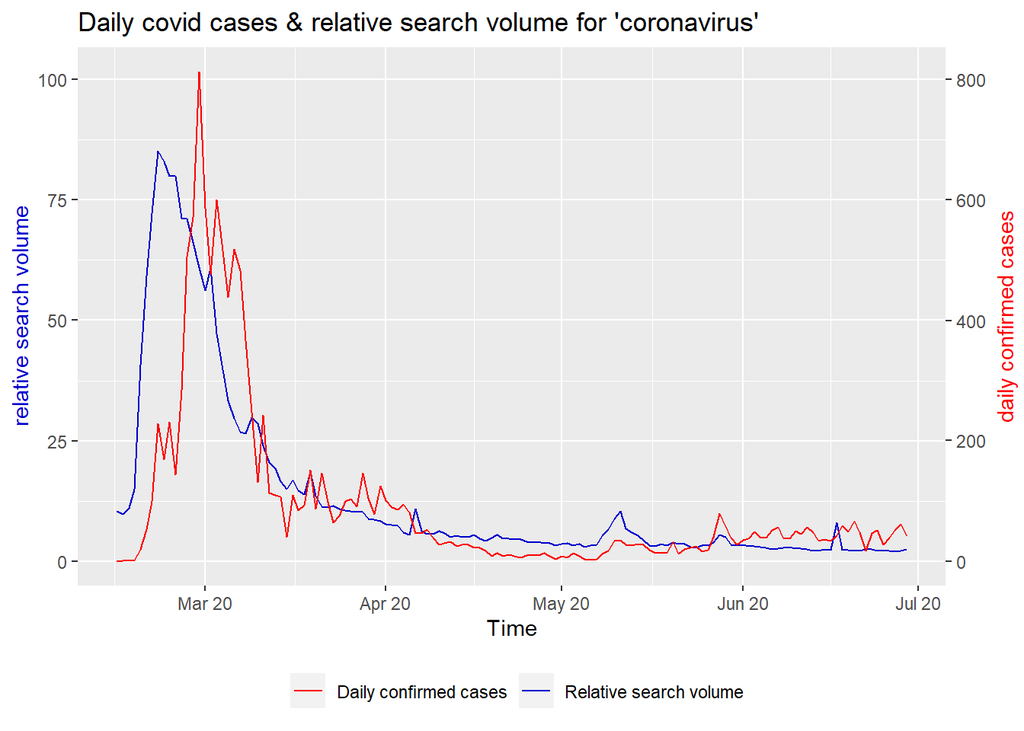

Above plot shows the relative search volume of the term “coronavirus” and the daily cases by time. To account for the different units of both variables, use a second y-axis. It can be deduced that the course of both variables is quite similar. We therefore calculate the pearson correlation:

```
## [1] 0.6864102
```

To account for the time lag we see in above plot, we calculate the cross correlation:

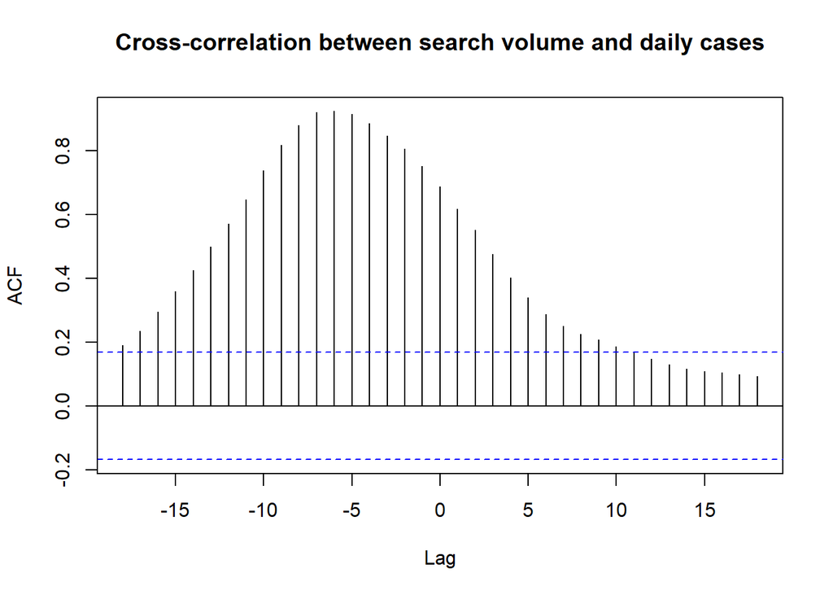

```
##
## Autocorrelations of series 'X', by lag
##
##   -18   -17   -16   -15   -14   -13   -12   -11   -10    -9    -8    -7    -6
## 0.189 0.235 0.295 0.359 0.425 0.499 0.570 0.646 0.737 0.816 0.878 0.919 0.923
##    -5    -4    -3    -2    -1     0     1     2     3     4     5     6     7
## 0.914 0.885 0.845 0.806 0.751 0.686 0.618 0.551 0.476 0.401 0.338 0.287 0.250
##     8     9    10    11    12    13    14    15    16    17    18
## 0.224 0.206 0.186 0.166 0.147 0.130 0.115 0.108 0.105 0.097 0.093
```

The cross correlation result suggests that the search volume correlates most (0.92) with daily cases at a time gap of 6 days, meaning that an increase of searches best reflects increased number of daily cases six days later, with a strong positive correlation.

Given those indicative results, we apply the pearson correlation test to check whether we are able to reject our null hypothesis of not correlated variables:

```
##
##  Pearson's product-moment correlation
##
## data:  merged_dt1$daily_cases and merged_dt1$coronavirus
## t = 10.926, df = 134, p-value < 2.2e-16
## alternative hypothesis: true correlation is not equal to 0
## 95 percent confidence interval:
##  0.5857590 0.7662109
## sample estimates:
##       cor
## 0.6864102
```

We see that the p-value is very low, allowing us to reject the null hypothesis - which indicates that there is indeed a correlation between search volume and daily cases. To further visualize this result, we use permutation testing (1000 times):

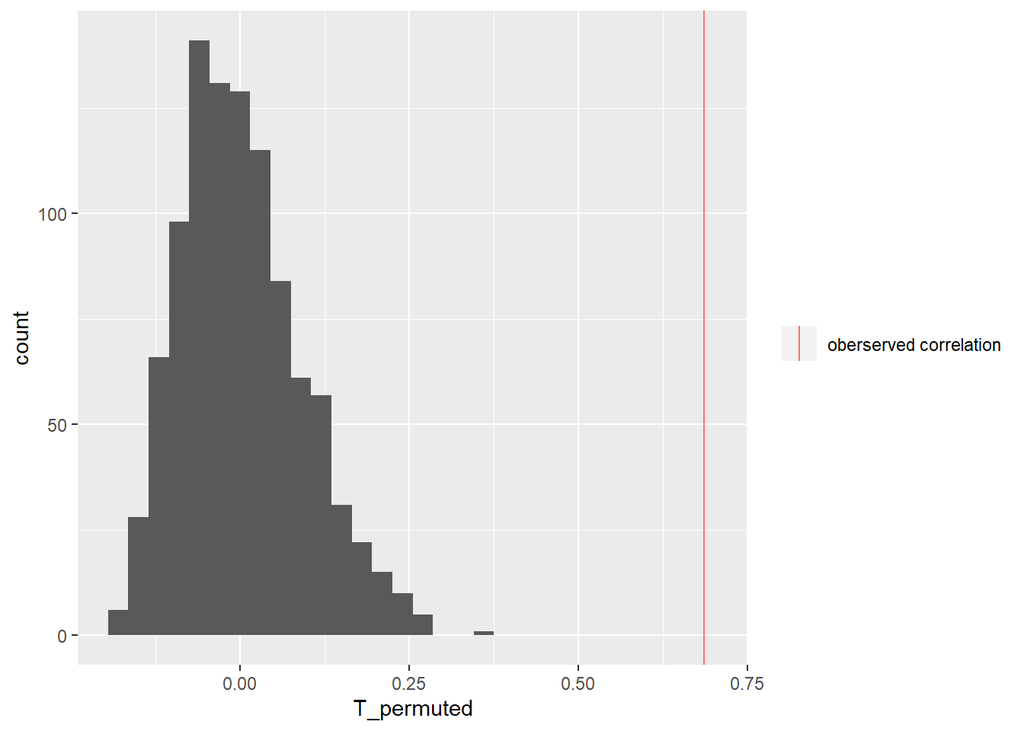

As the permutation plot shows, it is very unlikely that our observed correlation has arisen by chance.

**Short Discussion:** Above results suggest that internet searches for “coronavirus” indicate future covid cases with a time gap of 6 days.

**Investigating confounding variables:** But could there by an additional confounding variable distorting above result? Considering there have been superspreader events in the beginning of the pandemic (e.g. church gatherings), we further investigate if such superspreader events accelerated the dynamic of the pandemic, which would weaken our claim of using search data as possible prediction of outbreaks.

We first select the biggest superspreader event in the beginning of the pandemic: the “Shincheonji Church” Our approach is similar as before: We plot both variables (now cases of Shincheonji church and total daily cases) and calculate the Pearson correlation. Finally we test whether a possible association is significant (if null-hypothesis can be rejected) by applying the Pearson correlation test:

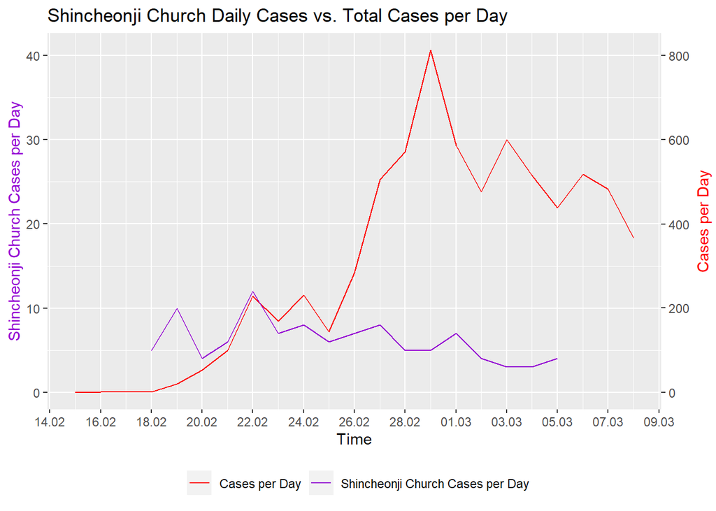

```
## [1] -0.02380472
```

```
##
##  Pearson's product-moment correlation
##
## data:  merged_dt2$daily_cases and merged_dt2$dailychurchcases
## t = -0.20758, df = 76, p-value = 0.8361
## alternative hypothesis: true correlation is not equal to 0
## 95 percent confidence interval:
##  -0.2450374  0.1997844
## sample estimates:
##         cor
## -0.02380472
```

Above results show no significant association of both variables; we can not reject the null hypothesis of not correlated data.